Juicios de aceptabilidad del español:  
Cuándo y cómo llevar a cabo un experimento formal

Santiago Gualchi - **FFyL-UBA**

Federico Alvarez - **FFyL-UBA**

Laura Tallon - **FFyL-UBA**

Charo Zacchigna - **FFyL-UBA**

## Introducción

## Juicios informales y formales

Juicios introspectivos del investigador y sus colegas sobre unas pocas oraciones

**vs**

Juicios de mayor cantidad de sujetos naive, varias lexicalizaciones y análisis cuantitativo

## Juicios informales y formales

- Ciertos autores sostienen que los juicios informales son confiables y no deben ser descartados. Incluso se han hecho experimentos formales a partir de juicios introspectivos que consiguieron un 95% y 98% de replicabilidad (Featherston 2009, Sprouse 2007, 2012, Sprouse y Almeida 2012, 2017, Sprouse y Schütze 2013, 2017, Sprouse, Almeida y Schütze 2013, Muñoz Perez 2014).

## Juicios informales y formales

- Otros critican la elección de los juicios clásicos en los que se basaron dichos experimentos y consideran que es necesaria una metodología formal con análisis cuantitativo (Gibson y Fedorenko 2013, Gibson, Piantadosi y Fedorenko 2013).
- Una tercera posición plantea la necesidad de experimentos formales solo en ciertos tipos de juicios (Marantz 2005, Linzen y Oseki 2018).

## Tipos de juicios según Marantz (2005)

### **Clase I**

1. *Man the book a women those to given has.

### **Clase II**

2. A. The scared man jumped from his seat.  
   B. *The man scared jumped from his seat.
3. A. The men are leaving.  
   B. *The men is leaving.

## Tipos de juicios según Marantz (2005)

### **Clase III**

> judgments about locality domains for long-distance dependencies (i.e., constraints on wh- movement), judgments about possible co-reference among discourse entities (as for “binding theory”) and judgments about semantic scope, e.g., relative scope of quantifiers (p. 434).

**Solo con estos últimos un experimento formal es**  
**“posible y útil”.**

## Linzen y Oseki (2018)

- La literatura del debate se restringe al inglés.
- Podría haber una diferencia en la replicabilidad de juicios de una lengua a otra.
- Los juicios elegidos en los experimentos formales son tomados al azar, de modo que hay muchos de tipo II → inflación en las tasas de replicabilidad.
- Los experimentos formales son necesarios para los juicios de tipo III considerados “cuestionables”.
- Experimento en hebreo y japonés: solo la mitad y un tercio de los contrastes se replican → Los lingüistas son capaces de advertir cuáles juicios son cuestionables y cuáles no.

## Experimento

## Corpus

1. CT: Nos vio a mí y al doctor.
2. CUC: *Lo vio a mí y a tu amigo.
3. LDxCPC: Te vi a vos ayer y a tu hermana hoy.
4. LCxCPC: Te vi a vos y a tu hermana juntos.

## Marco teórico

- Sistema *probe*-*goal* (2000, 2001)
- Enfoque estructural de la elipsis (Saab 2008, Gallego 2011, Merchant 2016)
- Enfoque binario y endocéntrico de la coordinación (Johannessen 1996, Camacho 2003, Zhang 2010)
- Conjunción proyecta un SD (Zhang 2010)

## Predicciones

- Si vamos un poco más lejos, de estos análisis se desprenden las siguientes predicciones.

## Por lo tanto

Si no es el caso que:

- LCxCPC: Me conoció a mí y al ingeniero juntos.
- LDxCPC: Me conoció a mí ayer y al ingeniero hoy.
- LCxCUC: *Lo conoció a mí y al ingeniero juntos.
- LDxCUC: *Lo conoció a mí ayer y al ingeniero hoy.
- LCxCT: Nos conoció a mí y a al ingeniero juntos.
- LDxCT: *Nos conoció a mí ayer y al ingeniero hoy.

entonces [es posible que] el marco teórico o el análisis sean incorrectos.

## Objetivo

- Verificar que el marco teórico predice correctamente la pertenencia o no (respectivamente) al español rioplatense para las construcciones mencionadas.

## Diseño experimental

### Participantes (260)

- Argentinos (CABA y pcia. de Bs. As.)
- Español rioplatense como L1
- 16 a 65 años (mediana: 26, IQR: 10)

## Diseño experimental

### Materiales

- Lista de estímulos presentada a través de Google Forms
- Escala de Likert de 1 a 5 según “naturalidad” con 58 estímulos:
  - 18 ítems experimentales
  - 36 fillers
  - 4 ítems de práctica

## Diseño experimental - Estímulos

### Ítems experimentales (18)

Según lectura (colectiva: LC; distributiva: LD) y concordancia (total: CT; con el primer coordinado: CPC; con el último coordinado: CUC):

- 3 ítems con LC y CT: *Nos conoció a mí y al ingeniero juntos.*
- 3 ítems con LC y CPC: *Me entrenó a mí y al futbolista juntos.*
- 3 ítems con LC y CUC: *Lo recibió a vos y a tu hermano juntos.*
- 3 ítems con LD y CT: *Los cuidó a ella el lunes y al bebé el viernes.*
- 3 ítems con LD y CPC: *Te saludó a vos en la puerta y al dueño en el jardín.*
- 3 ítems con LD y CUC: *Lo abrazó a mí antes y a tu primo después.*

## Diseño experimental - Estímulos

### Fillers (36)

- 18 inaceptables: *Los nadó a los alumnos.*
- 18 aceptables: *Lo mató al soldado.*

Todos comenzaban con un pronombre a fin de “esconder” los ítems experimentales.

## Diseño experimental - Estímulos

### Ítems de prueba (4)

- Buenos: *Mi hermano y sus amigos juegan a las cartas.*
- Malos: *Mi pez tengamos hambre.*

Todos estaban resueltos y acompañados de un texto explicativo sobre la resolución.

## Diseño experimental

### Procedimiento

- Datos personales: edad, género, nivel de estudios, carrera, profesión, residencia en sus primeros 10 años, idioma en el que le hablaron los padres y finalmente nivel de otro/s idiomas
- Consigna e ítems de práctica
- Estímulos en orden pseudoaleatorio
- Agradecimiento y mail de contacto

* La participación fue totalmente anónima

## Resultados

[figure not shown]

- En 5 de 6 casos, los resultados se hallan completamente polarizados
- Condición DT tiene mediana 4 y moda 5

## Resultados

[figure not shown]

- CP, CT y DP similares entre sí
- CU y DU similares entre sí
- DT en lugar intermedio

## Resultados

Modelo lineal con efectos mixtos

puntaje ~ Lectura*Concordancia + (1+Lectura*Concordancia|sujeto) + (1|oracion)

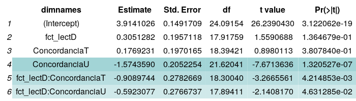

## Resultados

[figure not shown]

Comparaciones múltiples

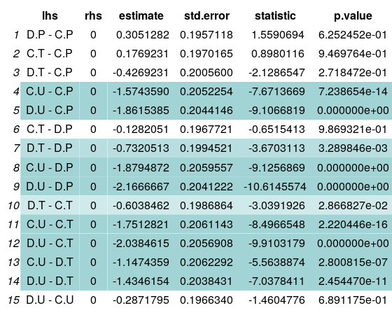

## Discusión

## Clíticos

- Se observa que para 5 de los 6 casos las predicciones se corresponden con los juicios de los hablantes.

## Clíticos

- Nos conoció a mí y a al ingeniero juntos. 😀
- *Nos conoció a mí ayer y al ingeniero hoy. 😭
- Me conoció a mí y al ingeniero juntos. 😀
- Me conoció a mí ayer y al ingeniero hoy. 😀
- *Lo conoció a mí y al ingeniero juntos. 😀
- *Lo conoció a mí ayer y al ingeniero hoy. 😀

## Conclusiones metodológicas

- Diferencias significativas graduadas; respuestas binarias no dan cuenta de contrastes (caso DT)
- Hay diferencias sólo visibles en las interacciones entre variables
- Posibilidad de considerar la variación individual en el modelo
- Posibilidad de considerar el efecto de ítems particulares

## Direcciones futuras

- Completar cuadrado latino
- Reevaluar modelo utilizado; métodos bayesianos
- Analizar información adicional recolectada

## ¡Gracias!

Grupo de Estadística para el Estudio del Lenguaje

gesel.contacto@gmail.com

https://gesel.github.io

Facebook: @geselba